# Elder Research Data Project

The goal of this project is to build a predictive model that would provide us with insight on Autism Spectrum Disorder diagnosis.

Steps for Review 1. Familiarize myself with the data 2. Determine what additinoal information would be helpful to know 3. Conduct exploratory analysis 4. Build a predictive model 5. Test performance 6. Iterate 7. Summarize findings

```r
load(".RData")
```

**Libraries used**

```r
library(data.table) #load data
library(tidyverse) #to manipulate data
library(psych) #summarizing data
library(stringr) #manipulate strings
library(ggplot2) #plot data points
library(party) #decision tree
library(rpart) #decision tree
library(rpart.plot)
library(rattle) #fancy rpart plot
library(ROCR)#test performance
```

**Data Review**

One of the very first steps I engaged in is to try to understand the data and determine what might be missing. In looking at the data a number of questions emerged that I felt could provide additional insight.

Below are some of these questions: * Is there a data dictionary that comes along with the data set? * What do the questions represent? * Are there questions that are more important than others? * How often can an individual complete the test? * Do some of the tests represent the same individual but filled out by different people?

Because I couldn’t answer these questions on my own I made some assumptions about the data. I assumed that each row represented one unique individual and that there were no duplicates. I also assumed that all questions carried equal weight.

**Exploring the Dataframe**

```r
#upload data
autism_data_or <- fread("Autism-Adult-Data (2).csv", header = TRUE)
```

Because a column summing the question scores existed I decided to remove columns 1 through 10 before continuing to explore the dataset.I also further explored the columns to get a better sense of the categorical values.

```r
#remove questions A1 through A10
autism_data <- autism_data_or[, -c(1:10)]

#inspect data
str(autism_data)
summary(autism_data)

unique(autism_data$Ethnicity)
unique(autism_data$Relation)
unique(autism_data$Country_of_res)
unique(autism_data$Age_desc)
```

**Cleaning Up the Data**

After reviewing the data I did some quick clean-up to make sure it was easier to use the data.

```r
#remove single quotes
autism_data$Ethnicity <- gsub("'", "", autism_data$Ethnicity)
autism_data$Relation <- gsub("'", "", autism_data$Relation)
autism_data$Country_of_res <- gsub("'", "", autism_data$Country_of_res)
autism_data$Age_desc <- gsub("'", "", autism_data$Age_desc)

#change ? to unknowns
autism_data$Ethnicity[autism_data$Ethnicity == '?'] <- "Unknown"
autism_data$Ethnicity[autism_data$Ethnicity == 'others'] <- "Others"
autism_data$Relation[autism_data$Relation == '?'] <- "Unknown"
autism_data$Age[autism_data$Age == '?'] <- NA

#added turkish to middle eastern category
#combined latino to hispanic
#after further inspection noticed that middle eastern label had an extra space
autism_data$Ethnicity[autism_data$Ethnicity == 'Latino'] <- "Hispanic"
autism_data$Ethnicity[autism_data$Ethnicity == 'Turkish'] <- "Middle Eastern"
autism_data$Ethnicity[autism_data$Ethnicity == 'Middle Eastern '] <- "Middle Eastern" #removed extra space

#Created an age category
#breaking down to under 18, 18 to 35, 36 to 55, 55+
autism_data[Age <= 18, Age_Group := "Under 18"]
autism_data[Age >18 & Age <36, Age_Group := "18 to 35"]
autism_data[Age >35 & Age <56, Age_Group := "36 to 55"]
autism_data[Age >55, Age_Group := "55+"]

autism_data$Age_Group <- factor(autism_data$Age_Group,
                                levels = c("Under 18", "18 to 35", "36 to 55", "55+"))

#Remove Age desc column because it was not a useful column
colnames(autism_data)
```

```
##  [1] "Age"             "Gender"          "Ethnicity"
##  [4] "Jundice"         "Family"          "Country_of_res"
##  [7] "Used_app_before" "App_result"      "Age_desc"
## [10] "Relation"        "ASD"             "Age_Group"
```

```r
autism_data <- autism_data[, -9]
```

**Explore and Summarize Dataset**

```r
#summarize data by ASD
describe.by(autism_data, group = 'ASD')
```

```
##
##  Descriptive statistics by group
## group: NO
##                  vars   n  mean    sd median trimmed  mad min  max range
## Age*                1 513 29.11 18.18     26   27.22 7.41  17  383   366
## Gender*             2 515   NaN    NA     NA     NaN   NA Inf -Inf  -Inf
## Ethnicity*          3 515   NaN    NA     NA     NaN   NA Inf -Inf  -Inf
## Jundice*            4 515   NaN    NA     NA     NaN   NA Inf -Inf  -Inf
## Family*             5 515   NaN    NA     NA     NaN   NA Inf -Inf  -Inf
## Country_of_res*     6 515   NaN    NA     NA     NaN   NA Inf -Inf  -Inf
## Used_app_before*    7 515   NaN    NA     NA     NaN   NA Inf -Inf  -Inf
## App_result          8 515  3.63  1.54      4    3.69 1.48   0    6     6
## Relation*           9 515   NaN    NA     NA     NaN   NA Inf -Inf  -Inf
## ASD*               10 515   NaN    NA     NA     NaN   NA Inf -Inf  -Inf
## Age_Group*         11 513  2.14  0.53      2    2.13 0.00   1    4     3
##                   skew kurtosis   se
## Age*             14.49   276.86 0.80
## Gender*             NA       NA   NA
## Ethnicity*          NA       NA   NA
## Jundice*            NA       NA   NA
## Family*             NA       NA   NA
## Country_of_res*     NA       NA   NA
## Used_app_before*    NA       NA   NA
## App_result       -0.25    -0.57 0.07
## Relation*           NA       NA   NA
## ASD*                NA       NA   NA
## Age_Group*        0.42     1.03 0.02
## --------------------------------------------------------
## group: YES
##                  vars   n  mean    sd median trimmed   mad min  max range
## Age*                1 189 31.31 10.58     30   30.27 11.86  17   61    44
## Gender*             2 189   NaN    NA     NA     NaN    NA Inf -Inf  -Inf
## Ethnicity*          3 189   NaN    NA     NA     NaN    NA Inf -Inf  -Inf
## Jundice*            4 189   NaN    NA     NA     NaN    NA Inf -Inf  -Inf
## Family*             5 189   NaN    NA     NA     NaN    NA Inf -Inf  -Inf
## Country_of_res*     6 189   NaN    NA     NA     NaN    NA Inf -Inf  -Inf
## Used_app_before*    7 189   NaN    NA     NA     NaN    NA Inf -Inf  -Inf
## App_result          8 189  8.26  1.06      8    8.21  1.48   7   10     3
## Relation*           9 189   NaN    NA     NA     NaN    NA Inf -Inf  -Inf
## ASD*               10 189   NaN    NA     NA     NaN    NA Inf -Inf  -Inf
## Age_Group*         11 189  2.28  0.61      2    2.26  0.00   1    4     3
##                  skew kurtosis   se
## Age*             0.75    -0.16 0.77
## Gender*            NA       NA   NA
## Ethnicity*         NA       NA   NA
## Jundice*           NA       NA   NA
## Family*            NA       NA   NA
## Country_of_res*    NA       NA   NA
## Used_app_before*   NA       NA   NA
## App_result       0.26    -1.18 0.08
## Relation*          NA       NA   NA
## ASD*               NA       NA   NA
## Age_Group*       0.48     0.41 0.04
```

Autism Spectrum Disorder Diagnosis

```r
#cross tabs
table(autism_data$ASD)
```

```
##
##  NO YES
## 515 189
```

```r
prop.table(table(autism_data$ASD))
```

```
##
##        NO       YES
## 0.7315341 0.2684659
```

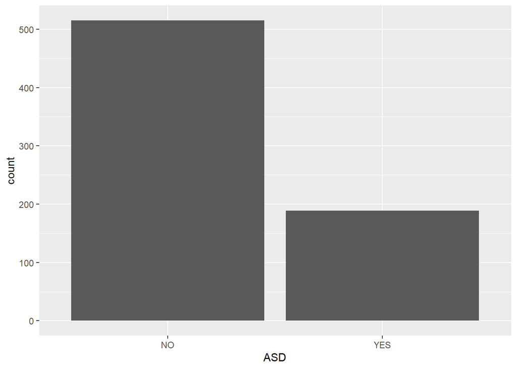

```r
ggplot(autism_data, aes(ASD)) +
  geom_bar()
```

Autism Spectrum Disorder Diagnosis by Ethnicity

```r
(race_table <- xtabs(~ Ethnicity + ASD, data = autism_data ))#ASD by Ethnicity
```

```
##                 ASD
## Ethnicity         NO YES
##   Asian          107  16
##   Black           25  18
##   Hispanic        18  15
##   Middle Eastern  89   9
##   Others          22   9
##   Pasifika        11   1
##   South Asian     33   3
##   Unknown         86   9
##   White-European 124 109
```

```r
prop.table(race_table,2)
```

```
##                 ASD
## Ethnicity                 NO         YES
##   Asian          0.207766990 0.084656085
##   Black          0.048543689 0.095238095
##   Hispanic       0.034951456 0.079365079
##   Middle Eastern 0.172815534 0.047619048
##   Others         0.042718447 0.047619048
##   Pasifika       0.021359223 0.005291005
##   South Asian    0.064077670 0.015873016
##   Unknown        0.166990291 0.047619048
##   White-European 0.240776699 0.576719577
```

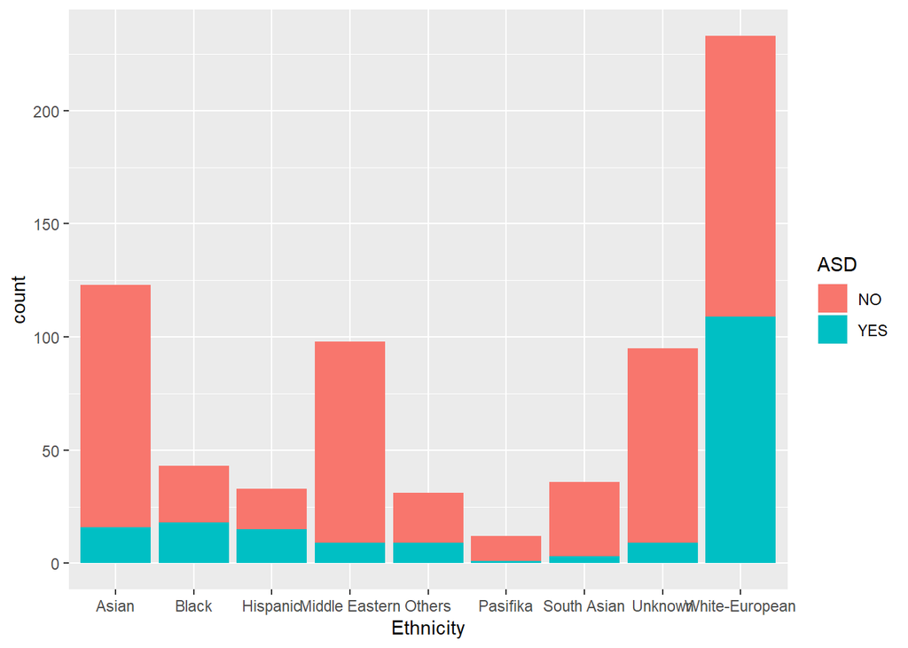

```r
ggplot(autism_data, aes(Ethnicity, fill = ASD)) +
  geom_bar()
```

Autism Spectrum Disorder Diagnosis by Gender

```r
(gender_table <-xtabs(~ Gender+ ASD, data = autism_data )) #ASD by Gender
```

```
##       ASD
## Gender  NO YES
##      f 234 103
##      m 281  86
```

```r
prop.table(gender_table, 2)
```

```
##       ASD
## Gender        NO       YES
##      f 0.4543689 0.5449735
##      m 0.5456311 0.4550265
```

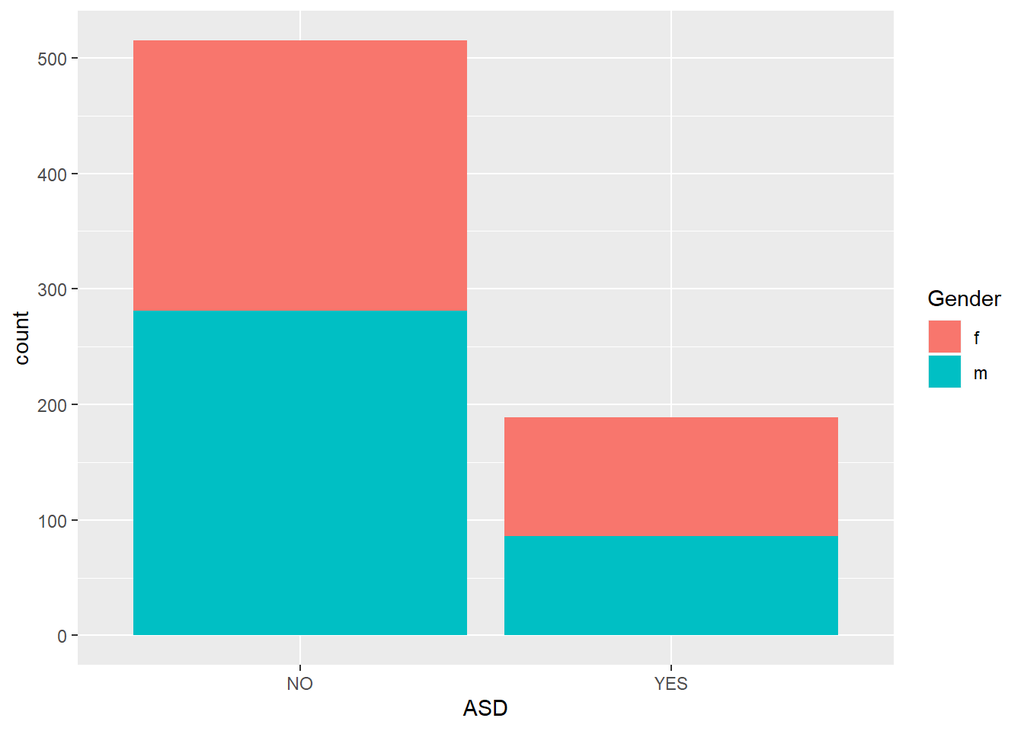

```r
ggplot(autism_data, aes(ASD, fill = Gender)) +
  geom_bar()
```

Autism Spectrum Disorder Diagnosis by Age Group

```r
(age_table <- xtabs( ~ Age_Group + ASD, data = autism_data)) #ASD by Age Group
```

```
##           ASD
## Age_Group   NO YES
##   Under 18  38  11
##   18 to 35 369 120
##   36 to 55 102  53
##   55+        4   5
```

```r
prop.table(age_table, 2)
```

```
##           ASD
## Age_Group           NO         YES
##   Under 18 0.074074074 0.058201058
##   18 to 35 0.719298246 0.634920635
##   36 to 55 0.198830409 0.280423280
##   55+      0.007797271 0.026455026
```

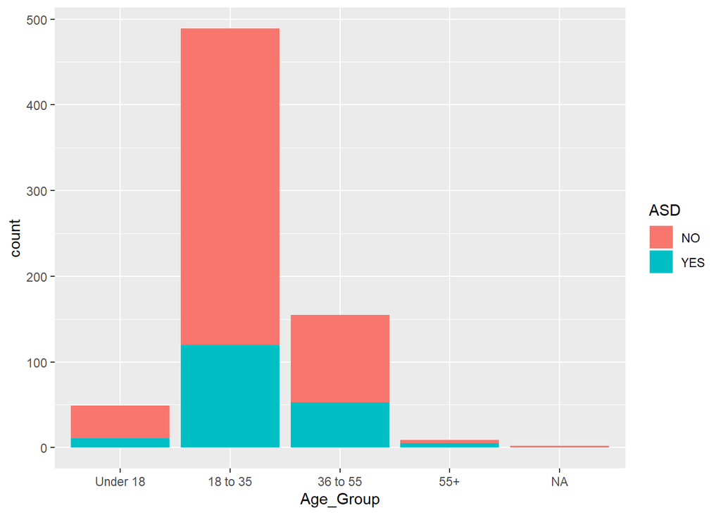

```r
ggplot(autism_data, aes(Age_Group, fill = ASD)) +
  geom_bar()
```

Autism Spectrum Disorder Diagnosis based on who filled out the form

```r
(relation_table <- xtabs( ~ Relation+ ASD, data = autism_data)) #ASD by relation
```

```
##                           ASD
## Relation                    NO YES
##   Health care professional   3   1
##   Others                     4   1
##   Parent                    38  12
##   Relative                  19   9
##   Self                     365 157
##   Unknown                   86   9
```

```r
prop.table(relation_table, 2)
```

```
##                           ASD
## Relation                            NO         YES
##   Health care professional 0.005825243 0.005291005
##   Others                   0.007766990 0.005291005
##   Parent                   0.073786408 0.063492063
##   Relative                 0.036893204 0.047619048
##   Self                     0.708737864 0.830687831
##   Unknown                  0.166990291 0.047619048
```

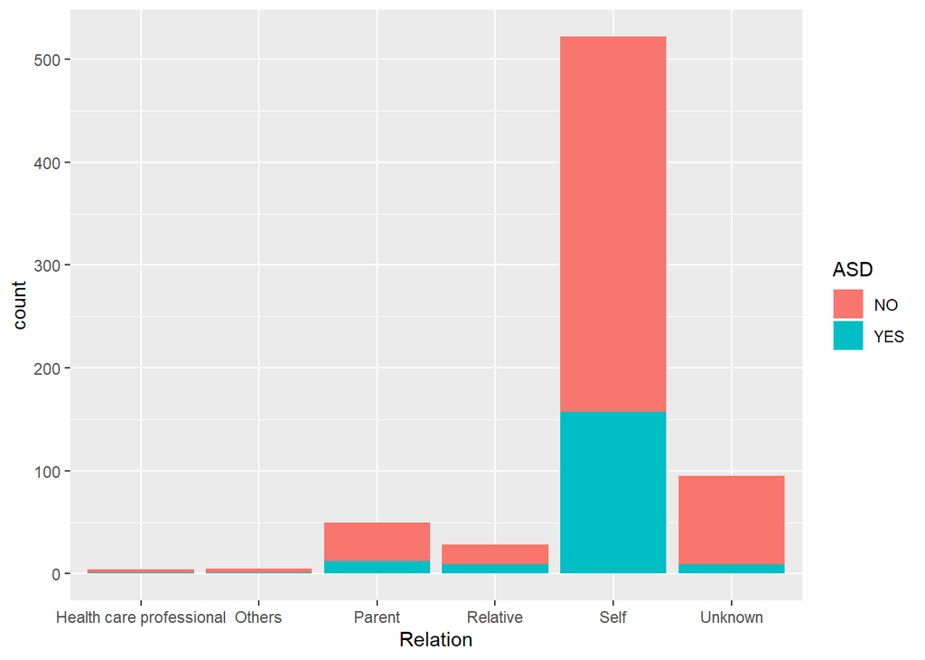

```r
ggplot(autism_data, aes(Relation, fill= ASD)) +
  geom_bar()
```

**Building a Predictive Model**

I assumed that the outcome of interest was ASD and determined a classification model using a Decision Tree could be a good way to predict ASD. Because I felt that the App Result captured the sum of A1 through A10 those columns were not included in the model.

I also decided to only select 9 out of the 11 variables I had kept because those were the ones I was most familiar with and felt could still provide predicitve insights.

```r
#turn all character variables into factors
autism_data2 <- autism_data %>%
  select(Age, Gender, Ethnicity, Family, Used_app_before, App_result, Age_Group, Relation, ASD) %>%
  mutate(Age = as.numeric(Age),
         Gender = factor(Gender),
         Ethnicity = factor(Ethnicity),
         Family = factor(Family),
         Used_app_before = factor(Used_app_before),
         Relation = factor(Relation),
         ASD = factor(ASD))

#Split data into training and test 70-30 split
set.seed(123)

train <- sample(nrow(autism_data2), 0.7*nrow(autism_data2), replace = FALSE)
TrainSet <- autism_data2[train,]
TestSet <- autism_data2[-train,]
summary(TrainSet)
summary(TestSet)
```

**Fit and Train Data**

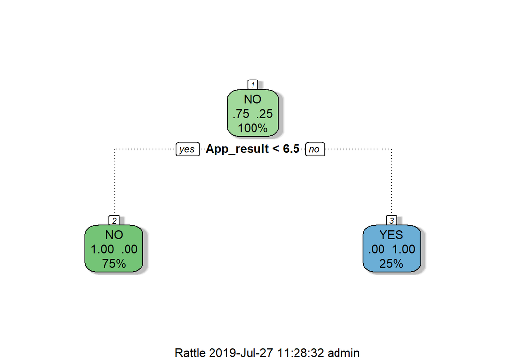

```r
fit <- rpart(ASD ~ Age+ Gender+ Ethnicity+ Family+ Used_app_before+App_result+ Age_Group+ Relation, data = TrainSet, method = "class")

fancyRpartPlot(fit)
```

This fit highlighted that app result is the definition for ASD. Having that variable in the feature is like having the outcome within the feature set. If you score above a 6 the answer was yes and it was a 100 percent accurate

My next step was to remove app results to see what kind of decision tree I would get.

[figure not shown]

```r
#removed app results to fit
fit2 <- rpart(ASD ~ Age+ Gender+ Ethnicity+ Family+ Used_app_before+ Age_Group+ Relation,
             data = TrainSet,
             method = "class")

fancyRpartPlot(fit2)
```

The decision tree above was so complex that I decided I needed to add controls and played with minsplit which allowed me to specify the minimum number of values I would like to see in a split.

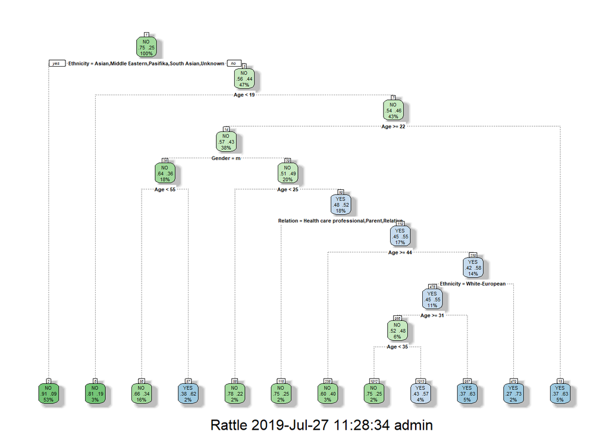

```r
#added controls to the fit
fit3 <- rpart(ASD ~ Age+ Gender+ Ethnicity+ Family+ Used_app_before+ Age_Group+ Relation,
                        data = TrainSet,
                        method = "class",
                  control = rpart.control(minsplit = 25, cp = 0.01))

fancyRpartPlot(fit3)
```

I felt like the decision tree was still hard to read and complex so I continued refining my minsplits keeping my complexity parameter at 0.01.

[figure not shown]

```r
#refined controls by manipulating minsplit
fit4 <- rpart(ASD ~ Age+ Gender+ Ethnicity+ Family+ Used_app_before+ Age_Group+ Relation,
                  data = TrainSet,
                  method = "class",
                  control = rpart.control(minsplit = 30, cp = 0.01))

fancyRpartPlot(fit4)
```

**Predict and look at performance for all 4 fits**

ALthough there was room for more refining of my decision trees I decided to look at the performance of each of the models I had built so far.

```r
#test the model and look at the AUC. the closer to one the stronger
TestSet$predict.score <- predict(fit, TestSet)[,2]
pred <- prediction(TestSet$predict.score, TestSet$ASD)
pfm <- performance(pred, "tpr", "fpr")
auc <- performance(pred, "auc")

TestSet$predict.score <- predict(fit2, TestSet)[,2]
pred <- prediction(TestSet$predict.score, TestSet$ASD)
pfm2 <- performance(pred, "tpr", "fpr")
auc2 <- performance(pred, "auc")


TestSet$predict.score <- predict(fit3, TestSet)[,2]
pred <- prediction(TestSet$predict.score, TestSet$ASD)
pfm3 <- performance(pred, "tpr", "fpr")
auc3 <- performance(pred, "auc")

TestSet$predict.score <- predict(fit4, TestSet)[,2]
pred <- prediction(TestSet$predict.score, TestSet$ASD)
pfm4 <- performance(pred, "tpr", "fpr")
auc4 <- performance(pred, "auc")
```

**Review Performance**

The higher the AUC the better the model is at predicting our outcome of interest.

```r
print(c(auc, auc2, auc3, auc4))
```

```
## [[1]]
## An object of class "performance"
## Slot "x.name":
## [1] "None"
##
## Slot "y.name":
## [1] "Area under the ROC curve"
##
## Slot "alpha.name":
## [1] "none"
##
## Slot "x.values":
## list()
##
## Slot "y.values":
## [[1]]
## [1] 1
##
##
## Slot "alpha.values":
## list()
##
##
## [[2]]
## An object of class "performance"
## Slot "x.name":
## [1] "None"
##
## Slot "y.name":
## [1] "Area under the ROC curve"
##
## Slot "alpha.name":
## [1] "none"
##
## Slot "x.values":
## list()
##
## Slot "y.values":
## [[1]]
## [1] 0.6808477
```

[output cut: 35 more lines]

```
## [1] "Area under the ROC curve"
##
## Slot "alpha.name":
## [1] "none"
##
## Slot "x.values":
## list()
##
## Slot "y.values":
## [[1]]
## [1] 0.670382
##
##
## Slot "alpha.values":
## list()
```

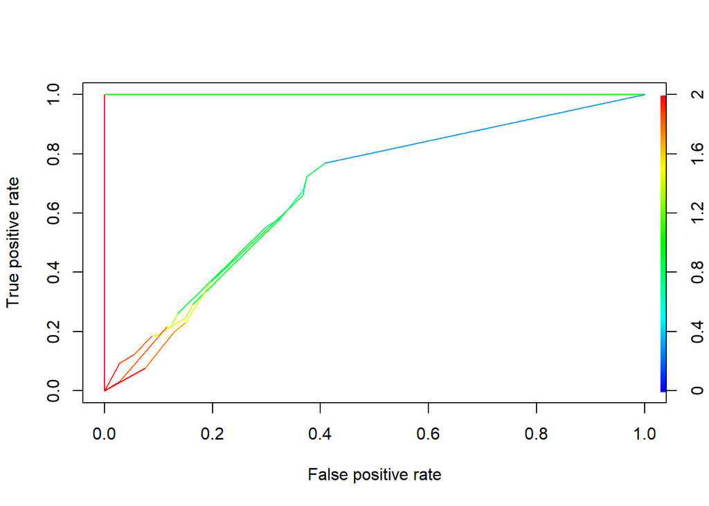

```r
plot(pfm, colorize = T)
plot(pfm2, add = T, colorize = T)
plot(pfm3, add = T, colorize = T)
plot(pfm4, add = T, colorize = T)
```

AUC was 1 for the first decision tree, 0.68 for the second, and 0.67 for the last two. There is definitely a lot of opportunity to improve on this model.

**Summary**

I spent about 4 hours on this project. If I had more time I would explore how adding the columns A1 through A10 would influence my model. I would try to explore if there are some questions that yield better predictions. I would think about using other models such as Random Forests.